# Research Question and Rationale

# Read in Counties shapefile into an sf dataframe, filtering for just NC counties

```r
#Read in Counties shapefile into an sf dataframe, filtering for just NC counties

NC_Counties_shp <- st_read(dsn = "./Data/Spatial/NC_Counties.shp") #Geospatial data for NC Counties
Landfills_shp <- st_read(dsn = "./Data/Spatial/ActivePermittedLandiflls.shp") #Active Landfills
IH_shp <- st_read(dsn = "./Data/Spatial/IH_Sites.shp") #Hazardous substance spill and disposal sites
FRB_shp <- st_read(dsn = "./Data/Spatial/FRB_Sites.shp") #Superfund
BF_shp <- st_read(dsn = "./Data/Spatial/BF_Sites.shp") #Brownfields
RUST_shp <- st_read(dsn = "./Data/Spatial/RUST.shp") #Underground Storage Tanks
HW_shp <- st_read(dsn = "./Data/Spatial/HW_Sites.shp") #Hazardous Waste Resource Conservation and Recovery Act
```

```r
#Reveal the CRS of the counties features so they can be graphed with NC Counties shapefile
st_crs(NC_Counties_shp)
```

```
## Coordinate Reference System:
##   EPSG: 4326
##   proj4string: "+proj=longlat +datum=WGS84 +no_defs"
```

```r
st_crs(Landfills_shp)
```

```
## Coordinate Reference System:
##   EPSG: 4326
##   proj4string: "+proj=longlat +datum=WGS84 +no_defs"
```

```r
st_crs(IH_shp)
```

```
## Coordinate Reference System:
##   EPSG: 4326
##   proj4string: "+proj=longlat +datum=WGS84 +no_defs"
```

```r
st_crs(FRB_shp)
```

```
## Coordinate Reference System:
##   EPSG: 3857
##   proj4string: "+proj=merc +a=6378137 +b=6378137 +lat_ts=0.0 +lon_0=0.0 +x_0=0.0 +y_0=0 +k=1.0 +units=m +nadgrids=@null +wktext +no_defs"
```

```r
st_crs(BF_shp)
```

```
## Coordinate Reference System:
##   No EPSG code
##   proj4string: "+proj=lcc +lat_1=34.33333333333334 +lat_2=36.16666666666666 +lat_0=33.75 +lon_0=-79 +x_0=609601.2199999997 +y_0=0 +datum=NAD83 +units=us-ft +no_defs"
```

```r
st_crs(RUST_shp)
```

```
## Coordinate Reference System:
##   EPSG: 4326
##   proj4string: "+proj=longlat +datum=WGS84 +no_defs"
```

```r
st_crs(HW_shp)
```

```
## Coordinate Reference System:
##   EPSG: 4326
##   proj4string: "+proj=longlat +datum=WGS84 +no_defs"
```

```r
#There is one row with an incorecct location; This site will be omitted in order to proceed with mapping data
Landfills_shp_mod <- subset(Landfills_shp, !LocationID == "P1252")

#Filter RUST dataset for only high risk UST sites since this inforation is available and due to the large amount of sites
levels(RUST_shp$ConfRisk)
```

```
## [1] "H" "I" "l" "L" "U"
```

```r
highrisk_RUST <- RUST_shp %>%
  filter(ConfRisk == "H")

#Join poverty data to county geospatial data
county_poverty_join <- NC_Counties_shp %>%
  left_join(y = Poverty_NC,by = c("CO_NAME" =  "Name"))


#Count the number of sites in each county; In some, the names of counties are not in all capital letters. In order to address future problems with joins, some were converted to all capital letters.
Sitecount_Landfill <- count(Landfills_shp_mod, Landfills_shp_mod$County)

levels(IH_shp$SITECOUNTY) <- toupper(levels(IH_shp$SITECOUNTY)) #all caps
Sitecount_IH <- count(IH_shp, IH_shp$SITECOUNTY)

Sitecount_FRB <- count(FRB_shp, FRB_shp$SITE_COUNT)

levels(BF_shp$BF_County) <- toupper(levels(BF_shp$BF_County))
Sitecount_BF <- count(BF_shp, BF_shp$BF_County)

levels(highrisk_RUST$County) <- toupper(levels(highrisk_RUST$County))
Sitecount_RUST <- count(highrisk_RUST, highrisk_RUST$County)

Sitecount_HW <- count(HW_shp, HW_shp$LOC_COUNTY)


#Join count dataframes with race info. Needed to make county names in Race_Processed data set capitalized so left join would work. In one case, Race_Processed data needed to add a column with abbreviations in order to join to the RUST data set.
Sitecount_Landfill_join <- left_join(Sitecount_Landfill, Race_Processed, by = c("Landfills_shp_mod$County" = "County"))
levels(Race_Processed$County) <- toupper(levels(Race_Processed$County))
Sitecount_IH_join <- left_join(Sitecount_IH, Race_Processed, by = c("IH_shp$SITECOUNTY" = "County"))
Sitecount_FRB_join <- left_join(Sitecount_FRB, Race_Processed,
  by = c("FRB_shp$SITE_COUNT" = "County"))
Sitecount_BF_join <- left_join(Sitecount_BF, Race_Processed, by = c("BF_shp$BF_County" = "County"))
Race_Processed_abv <- transform(Race_Processed, ABV = str_sub(Race_Processed$County, 1, 5))

Sitecount_RUST_join <- left_join(Sitecount_RUST, Race_Processed_abv, by = c("highrisk_RUST$County" = "ABV"))
Sitecount_HW_join <- left_join(Sitecount_HW, Race_Processed, by = c("HW_shp$LOC_COUNTY" = "County"))
```

# Analysis

```r
#Landfill
#Create clusters for low or high minority percent in each county
test <- pam(x = Sitecount_Landfill_join$MinorityPerc, k = 2, metric="manhattan")

PAMClust = rep("NA", length(Sitecount_Landfill_join$MinorityPerc))
PAMClust[test$clustering == 1] = "High"
PAMClust[test$clustering == 2] = "Low"
Sitecount_Landfill_join$Cluster = PAMClust

LF.count <- count(Sitecount_Landfill_join, Sitecount_Landfill_join$Cluster)
wilcox.test(Sitecount_Landfill_join$n ~ Sitecount_Landfill_join$Cluster)
```

```
##
##  Wilcoxon rank sum test with continuity correction
##
## data:  Sitecount_Landfill_join$n by Sitecount_Landfill_join$Cluster
## W = 691.5, p-value = 0.3187
## alternative hypothesis: true location shift is not equal to 0
```

```r
#P-value = 0.3187

#IH
test1 <- pam(x = Sitecount_IH_join$MinorityPerc, k = 2, metric="manhattan")
PAMClust1 = rep("NA", length(Sitecount_IH_join$MinorityPerc))
PAMClust1[test1$clustering == 1] = "High"
PAMClust1[test1$clustering == 2] = "Low"
Sitecount_IH_join$Cluster = PAMClust1

IH.count <- count(Sitecount_IH_join, Sitecount_IH_join$Cluster)
wilcox.test(Sitecount_IH_join$n ~ Sitecount_IH_join$Cluster)
```

```
##
##  Wilcoxon rank sum test with continuity correction
##
## data:  Sitecount_IH_join$n by Sitecount_IH_join$Cluster
## W = 1232.5, p-value = 0.6696
## alternative hypothesis: true location shift is not equal to 0
```

```r
#P-value = 0.6696

#FRB -error
#Sitecount_FRB_join$MinorityPerc = na.omit(Sitecount_FRB_join$MinorityPerc)
#test2 <- pam(x = FRB_x, k = 2, metric="manhattan")
#PAMClust2 = rep("NA", length(Sitecount_FRB_join$MinorityPerc))
#PAMClust2[test2$clustering == 1] = "High"
#PAMClust2[test2$clustering == 2] = "Low"
#Sitecount_FRB_join$Cluster = PAMClust2

#FRB.count <- count(Sitecount_FRB_join, Sitecount_FRB_join$Cluster)
#wilcox.test(Sitecount_IH_join$n ~ Sitecount_FRB_join$Cluster)

#BF
test3 <- pam(x = Sitecount_BF_join$MinorityPerc, k = 2, metric="manhattan")
PAMClust3 = rep("NA", length(Sitecount_BF_join$MinorityPerc))
PAMClust3[test3$clustering == 1] = "High"
PAMClust3[test3$clustering == 2] = "Low"
Sitecount_BF_join$Cluster = PAMClust3

BF.count <- count(Sitecount_BF_join, Sitecount_BF_join$Cluster)
wilcox.test(Sitecount_BF_join$n ~ Sitecount_BF_join$Cluster)
```

```
##
##  Wilcoxon rank sum test with continuity correction
##
## data:  Sitecount_BF_join$n by Sitecount_BF_join$Cluster
## W = 461, p-value = 0.6803
## alternative hypothesis: true location shift is not equal to 0
```

```r
#P-value = 0.6803

#RUST
test4 <- pam(x = Sitecount_RUST_join$MinorityPerc, k = 2, metric="manhattan")
PAMClust4 = rep("NA", length(Sitecount_RUST_join$MinorityPerc))
PAMClust4[test4$clustering == 1] = "High"
PAMClust4[test4$clustering == 2] = "Low"
Sitecount_RUST_join$Cluster = PAMClust4

RUST.count <- count(Sitecount_RUST_join, Sitecount_RUST_join$Cluster)
wilcox.test(Sitecount_RUST_join$n ~ Sitecount_RUST_join$Cluster)
```

```
##
##  Wilcoxon rank sum test with continuity correction
##
## data:  Sitecount_RUST_join$n by Sitecount_RUST_join$Cluster
## W = 1221.5, p-value = 0.7398
## alternative hypothesis: true location shift is not equal to 0
```

```r
#P-value = 0.7398

#HW
test5 <- pam(x = Sitecount_HW_join$MinorityPerc, k = 2, metric="manhattan")
PAMClust5 = rep("NA", length(Sitecount_HW_join$MinorityPerc))
PAMClust5[test5$clustering == 1] = "High"
PAMClust5[test5$clustering == 2] = "Low"
Sitecount_HW_join$Cluster = PAMClust5

HW.count <- count(Sitecount_HW_join, Sitecount_HW_join$Cluster)
wilcox.test(Sitecount_HW_join$n ~ Sitecount_HW_join$Cluster)
```

```
##
##  Wilcoxon rank sum test with continuity correction
##
## data:  Sitecount_HW_join$n by Sitecount_HW_join$Cluster
## W = 1137.5, p-value = 0.4177
## alternative hypothesis: true location shift is not equal to 0
```

```r
#P-value = 0.4177
```

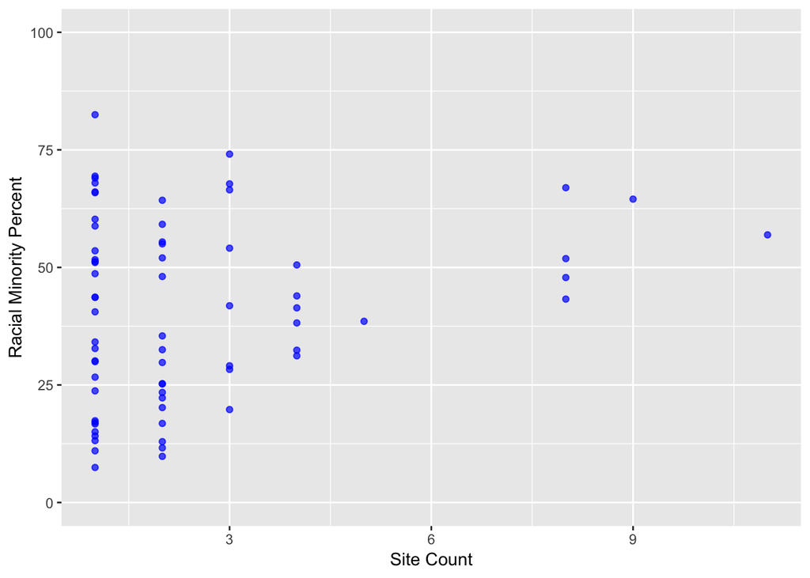

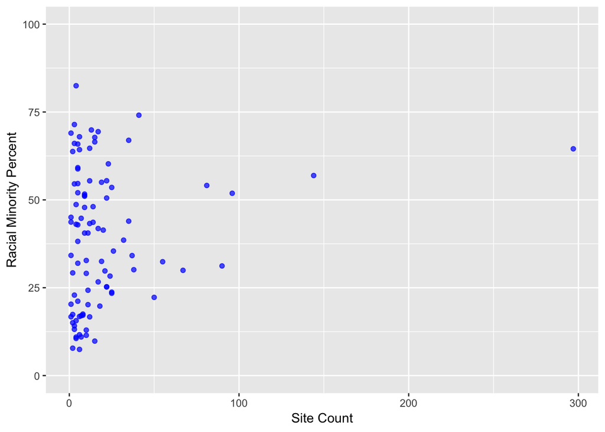

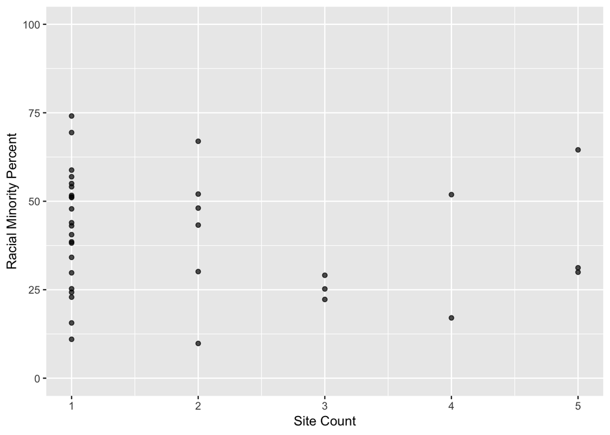

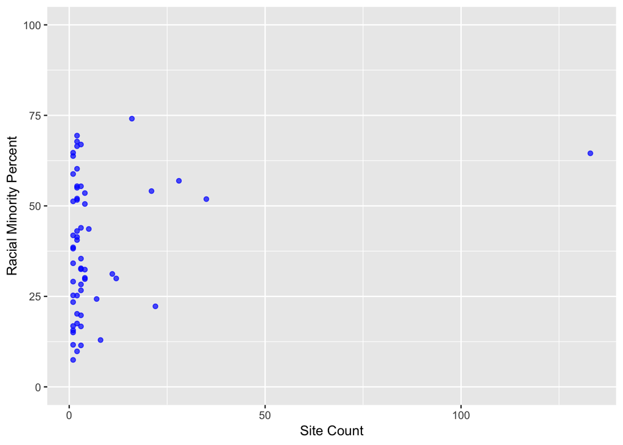

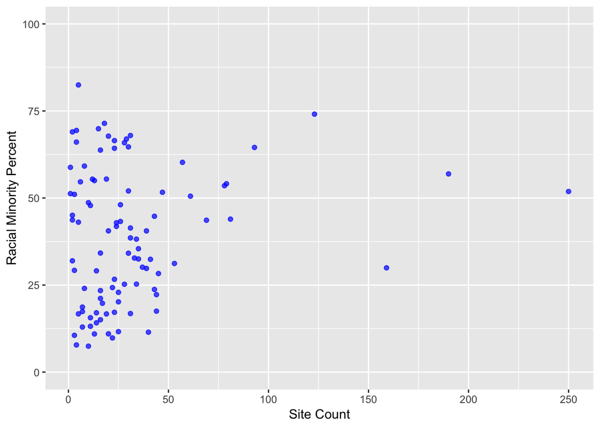

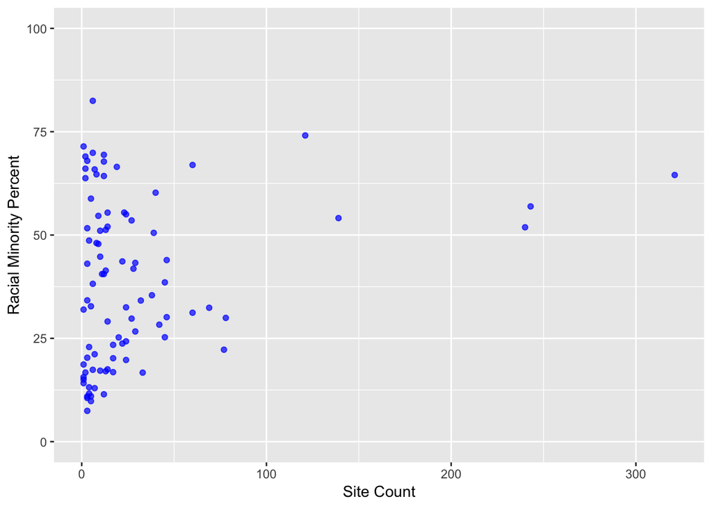

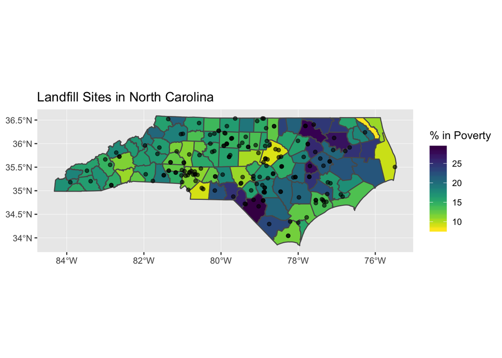

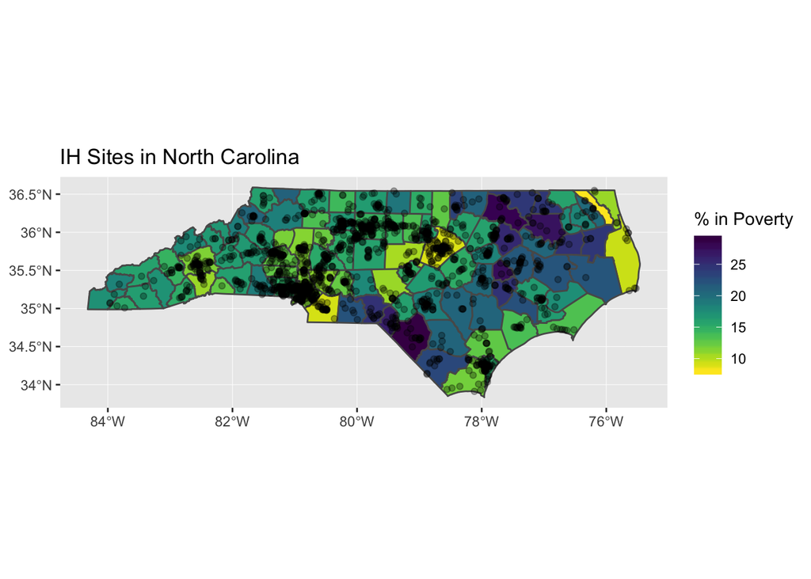

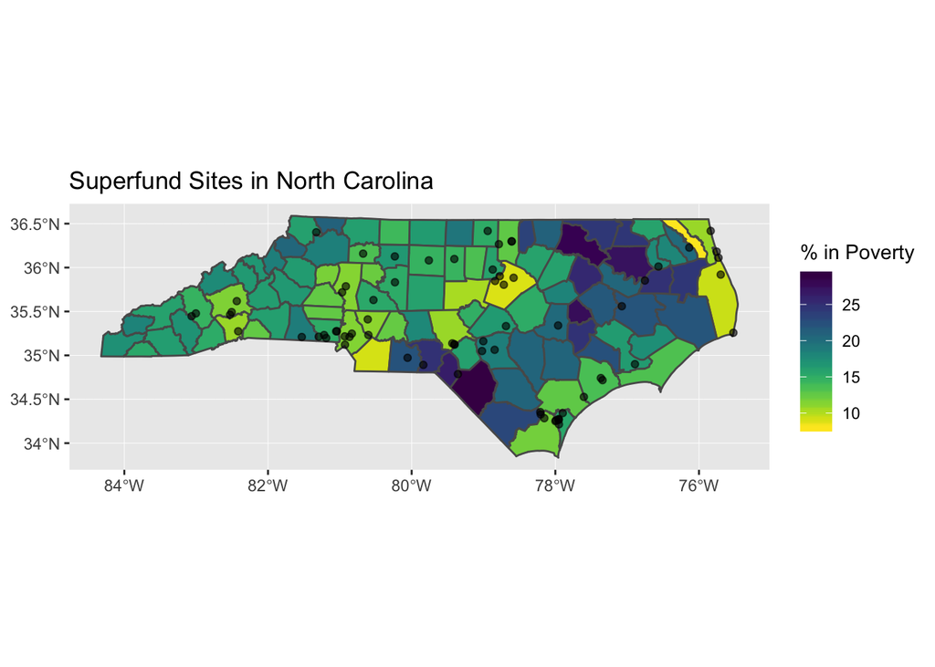

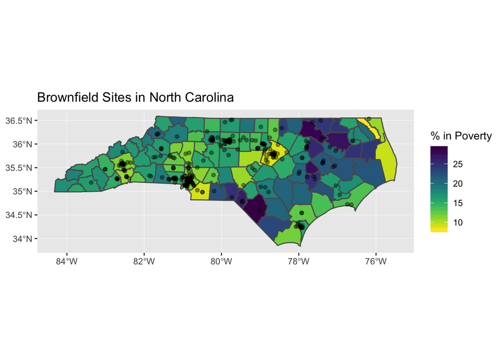

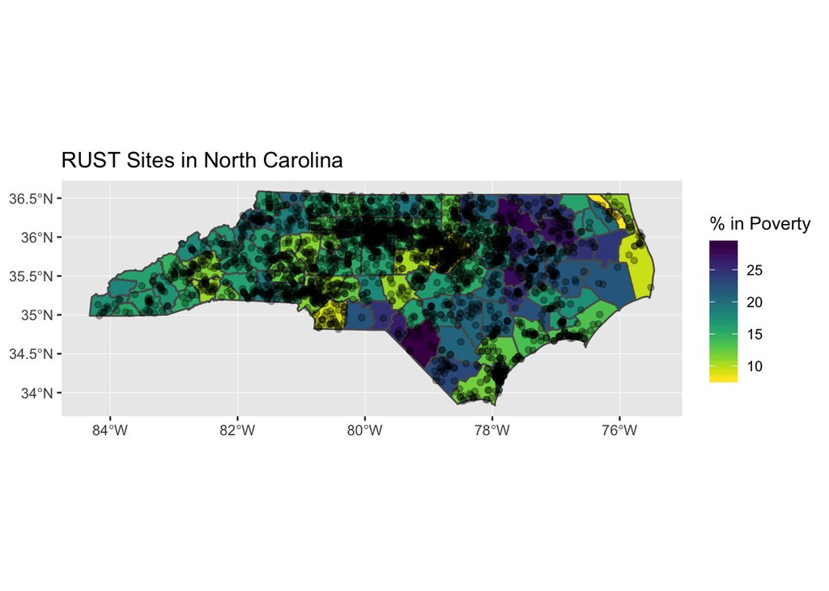

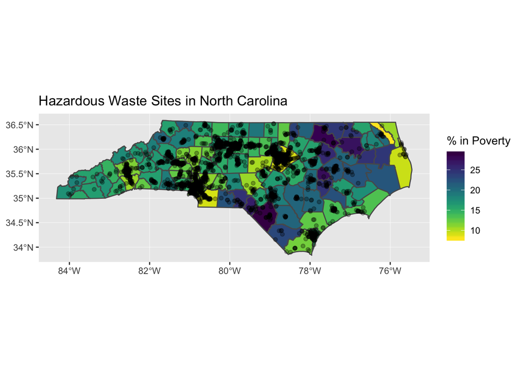

# Summary and Conclusions

Based on my performed analysis, there is no significant difference in the number of hazardous waste sites that exist in counties with majority racial minority populations.

# References

U.S. Census Bureau. (2018). Small Area Income and Poverty Estimates (SAIPE) Program. Retrieved from https://www.census.gov/programs-surveys/saipe/about.html

NC Budget and Management. (2019). LINC. Retrieved from https://www.osbm.nc.gov/facts-figures/linc